# Assignment-Online Retail Analytics

```r
library(dplyr)
Online_Retail<-read.csv("./Online_Retail.csv")
```

**1. Breakdown of the number of transactions by countries in both percentage and count, and showing the countries accounting for more than 1% of the total transactions:**

```r
trans_countries<-Online_Retail %>% group_by(Country) %>% summarise(cnt = n()) %>% mutate(perc =round((cnt/sum(cnt))*100,5)) %>% filter(perc>1)
head(trans_countries)
```

| Country | cnt | perc |
| --- | --- | --- |
| EIRE | 8196 | 1.51243 |
| France | 8557 | 1.57905 |
| Germany | 9495 | 1.75214 |
| United Kingdom | 495478 | 91.43196 |

**2. Creating a new variable TransactionValue and adding it to the dataframe:**

```r
TransactionValue<-Online_Retail$Quantity*Online_Retail$UnitPrice

#creating a dataframe and adding TransactionValue to it

Online_Retail_new<-data.frame(InvoiceNo=Online_Retail$InvoiceNo,StockCode= Online_Retail$StockCode,Description=Online_Retail$Description,Quantity=Online_Retail$Quantity, InvoiceDate=Online_Retail$InvoiceDate,UnitPrice=Online_Retail$UnitPrice, CustomerID=Online_Retail$CustomerID,Country=Online_Retail$Country,  TransactionValue=TransactionValue)
```

```r
Trans_value_countries<- Online_Retail_new %>% group_by(Country) %>% summarise(sum_TransactionValue = sum(TransactionValue)) %>% filter(sum_TransactionValue>130000)

head(Trans_value_countries)
```

| Country | sum_TransactionValue |
| --- | --- |
| Australia | 137077.3 |
| EIRE | 263276.8 |
| France | 197403.9 |
| Germany | 221698.2 |
| Netherlands | 284661.5 |
| United Kingdom | 8187806.4 |

**4. Optional question**

```r
Temp=strptime(Online_Retail_new$InvoiceDate,format='%m/%d/%Y %H:%M',tz='GMT')
head(Temp)
```

```
## [1] "2010-12-01 08:26:00 GMT" "2010-12-01 08:26:00 GMT"
## [3] "2010-12-01 08:26:00 GMT" "2010-12-01 08:26:00 GMT"
## [5] "2010-12-01 08:26:00 GMT" "2010-12-01 08:26:00 GMT"
```

```r
#New_Invoice_Date
Online_Retail_new$New_Invoice_Date<- as.Date(Temp)

Online_Retail_new$New_Invoice_Date[20000]- Online_Retail_new$New_Invoice_Date[10]
```

```
## Time difference of 8 days
```

```r
#Invoice_Week

Online_Retail_new$Invoice_Day_Week= weekdays(Online_Retail_new$New_Invoice_Date)

#Invoice_Hour

Online_Retail_new$New_Invoice_Hour = as.numeric(format(Temp, "%H"))

#Invoice_month

Online_Retail_new$New_Invoice_Month = as.numeric(format(Temp, "%m"))
```

**4(a). Percentage of transactions (by numbers) by days of the week**

```r
perc_transc<- Online_Retail_new %>% group_by(Invoice_Day_Week) %>% summarise(count=n()) %>% mutate(perc =round((count/sum(count))*100,5))

head(perc_transc)
```

| Invoice_Day_Week | count | perc |
| --- | --- | --- |
| Friday | 82193 | 15.16731 |
| Monday | 95111 | 17.55110 |
| Sunday | 64375 | 11.87930 |
| Thursday | 103857 | 19.16503 |
| Tuesday | 101808 | 18.78692 |
| Wednesday | 94565 | 17.45035 |

**4(b). Percentage of transactions (by transaction volume) by days of the week**

```r
perc_trans_week<- Online_Retail_new %>% group_by(Invoice_Day_Week) %>% summarise(Total=sum(TransactionValue)) %>% mutate(percentage = (Total/sum(Total))*100)
head(perc_trans_week)
```

| Invoice_Day_Week | Total | percentage |
| --- | --- | --- |
| Friday | 1540610.8 | 15.804787 |
| Monday | 1588609.4 | 16.297194 |
| Sunday | 805678.9 | 8.265282 |
| Thursday | 2112519.0 | 21.671867 |
| Tuesday | 1966182.8 | 20.170636 |
| Wednesday | 1734147.0 | 17.790232 |

**4(c). Percentage of transactions (by transaction volume) by month of the year**

```r
perc_trans_month<- Online_Retail_new %>% group_by(New_Invoice_Month) %>% summarise(Total=sum(TransactionValue)) %>% mutate(percentage = (Total/sum(Total))*100)
head(perc_trans_month)
```

| New_Invoice_Month | Total | percentage |
| --- | --- | --- |
| 1 | 560000.3 | 5.744919 |
| 2 | 498062.6 | 5.109515 |
| 3 | 683267.1 | 7.009487 |
| 4 | 493207.1 | 5.059703 |
| 5 | 723333.5 | 7.420519 |
| 6 | 691123.1 | 7.090080 |

**4(d). The date with the highest number of transactions from Australia**

```r
date_trans<- Online_Retail_new %>% filter(Country == 'Australia') %>% group_by(New_Invoice_Date) %>% summarise(count=n()) %>% arrange(desc(count))

head(date_trans)
```

| New_Invoice_Date | count |
| --- | --- |
| 2011-06-15 | 139 |
| 2011-07-19 | 137 |
| 2011-08-18 | 97 |
| 2011-03-03 | 84 |
| 2011-10-05 | 82 |
| 2011-05-17 | 73 |

```r
#Australia recorded highest number of transactions on 2011-06-15
```

**5. Histogram of transaction Values from Germany**

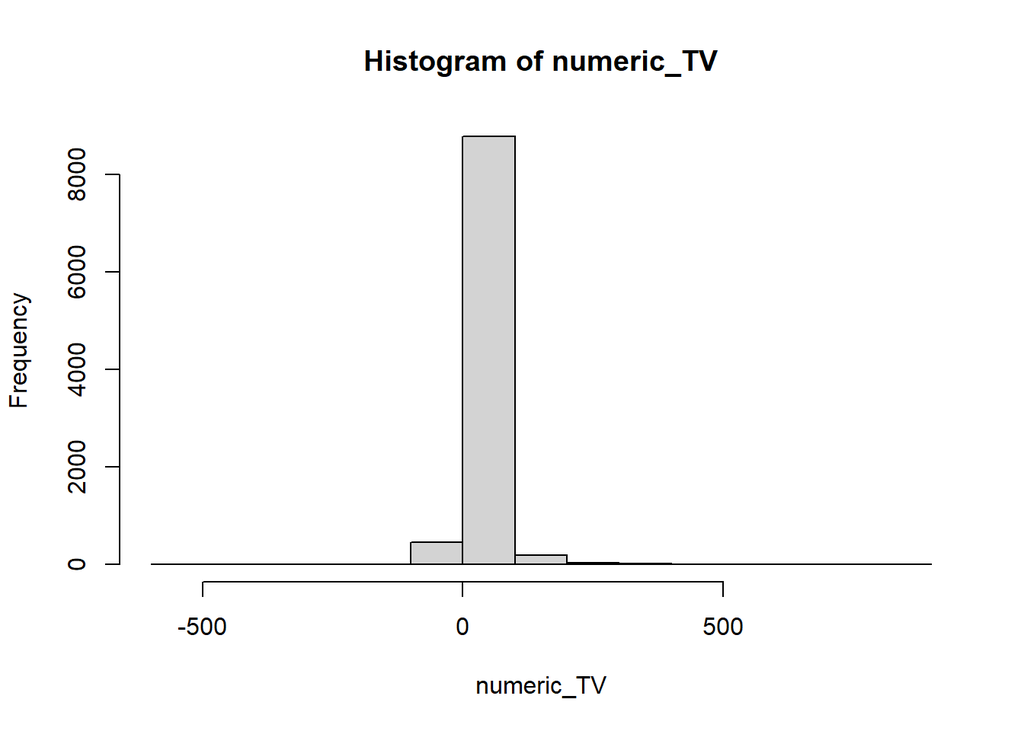

```r
histogram<- Online_Retail_new %>% filter(Country == 'Germany')
numeric_TV<- as.integer(histogram$TransactionValue)
hist(numeric_TV)
```

**6. Identifying the customer with highest number of transactions and finding the most valuable customer**

```r
cust_count<-Online_Retail_new %>% group_by(CustomerID) %>% summarise(cntt = n()) %>% arrange(desc(cntt))
head(cust_count)
```

| CustomerID | cntt |
| --- | --- |
| NA | 135080 |
| 17841 | 7983 |
| 14911 | 5903 |
| 14096 | 5128 |
| 12748 | 4642 |
| 14606 | 2782 |

```r
#Customer 17841 has the highest number of transactions.
```

```r
cust_sum<-Online_Retail_new %>% group_by(CustomerID) %>% summarise(sum_cnt =sum(TransactionValue)) %>% arrange(desc(sum_cnt))

head(cust_sum)
```

| CustomerID | sum_cnt |
| --- | --- |
| NA | 1447682.1 |
| 14646 | 279489.0 |
| 18102 | 256438.5 |
| 17450 | 187482.2 |
| 14911 | 132572.6 |
| 12415 | 123725.4 |

```r
#Customer 14646 is the most valuable
```

**7. Percentage of missing values for each variable in the dataset**

```r
missing_values<- (colMeans(is.na(Online_Retail_new))*100)

missing_values
```

```
##         InvoiceNo         StockCode       Description          Quantity
##           0.00000           0.00000           0.00000           0.00000
##       InvoiceDate         UnitPrice        CustomerID           Country
##           0.00000           0.00000          24.92669           0.00000
##  TransactionValue  New_Invoice_Date  Invoice_Day_Week  New_Invoice_Hour
##           0.00000           0.00000           0.00000           0.00000
## New_Invoice_Month
##           0.00000
```

```r
missing<-Online_Retail_new %>% filter(is.na(CustomerID)) %>% group_by(Country) %>% summarise(count_by_countries = n())

View(missing)
```

**9. On average, how often the costumers comeback to the website for their next shopping?**

```r
difference_days<-Online_Retail_new %>% select(CustomerID,New_Invoice_Date) %>% group_by(CustomerID) %>% distinct(New_Invoice_Date) %>% arrange(desc(CustomerID)) %>% mutate(days = New_Invoice_Date-lag(New_Invoice_Date)) %>% filter(!is.na(days))
View(difference_days)
mean(difference_days$days)
```

```
## Time difference of 38.4875 days
```

```r
# On an average,customers come back after 38 days to the website for their next shopping.
```

**10. Return rate for the French customers**

```r
cancelled_customers <- Online_Retail_new %>% filter(Country=='France',Quantity<0) %>% summarise(count = n())
Total_customers<-  Online_Retail_new %>% filter(Country=='France') %>% count()

return_rate_french_cust=((cancelled_customers/Total_customers)*100)

head(return_rate_french_cust)
```

|  | count |
| --- | --- |
| 1 | 1.741264 |

**11. Product that has generated the highest Revenue for the retailer**

```r
item_sum<-Online_Retail_new %>% group_by(Description) %>% summarise(sum_cnt = sum(TransactionValue)) %>% arrange(desc(sum_cnt))
head(item_sum)
```

| Description | sum_cnt |
| --- | --- |
| DOTCOM POSTAGE | 206245.48 |
| REGENCY CAKESTAND 3 TIER | 164762.19 |
| WHITE HANGING HEART T-LIGHT HOLDER | 99668.47 |
| PARTY BUNTING | 98302.98 |
| JUMBO BAG RED RETROSPOT | 92356.03 |
| RABBIT NIGHT LIGHT | 66756.59 |

```r
#DOTCOM POSTAGE generates highest revenue for the retailer
```

**12. Unique customers in the dataset**

```r
unique_cust<- Online_Retail_new %>% distinct(CustomerID) %>% summarise(ncount = n())
head(unique_cust)
```

|  | ncount |
| --- | --- |
| 1 | 4373 |

```r
 #There are 4373 unique customers in the dataset
```